# Hw1

the code chunk below will generate the average blood pressure by stress level

```
##   stress      sbp
## 1     HS 147.0172
## 2     LS 142.3510
## 3     MS 145.1429
```

The systolic blood pressures by stress level appear similar by standard deviation.

```
##   stress      sbp
## 1     HS 28.03991
## 2     LS 28.28667
## 3     MS 27.67478
```

The medium exercise level has the lowest age.

```
##   exercise      age
## 1        H 41.34320
## 2        L 39.80000
## 3        M 39.33824
```

The Low exercise group differs the most with its mean.

```
##   exercise      age
## 1        H 12.33561
## 2        L 14.13980
## 3        M 13.20618
```

As the level of education increases, average age tends to decrease, also the variance of the age tends to increase as the level of education increases.

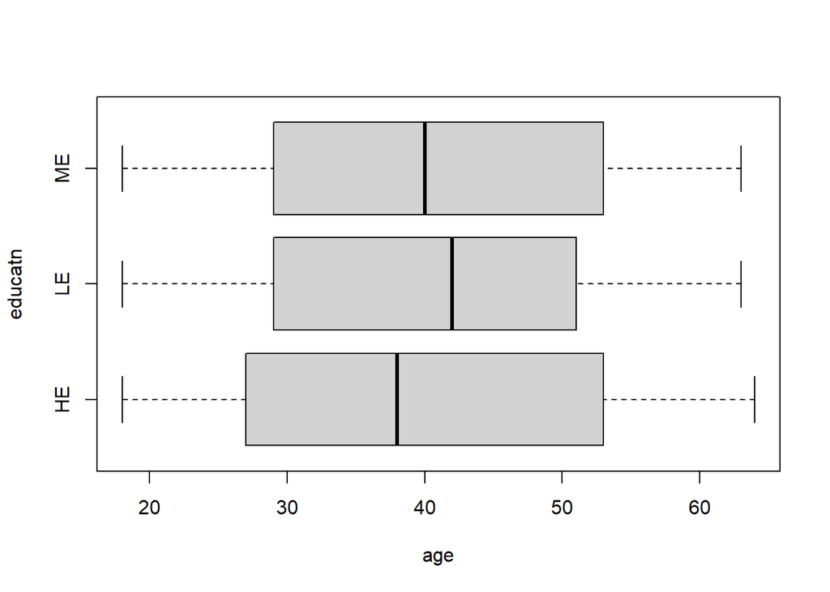

People who are married tend to have a higher variance in blood pressure than those who are not married.

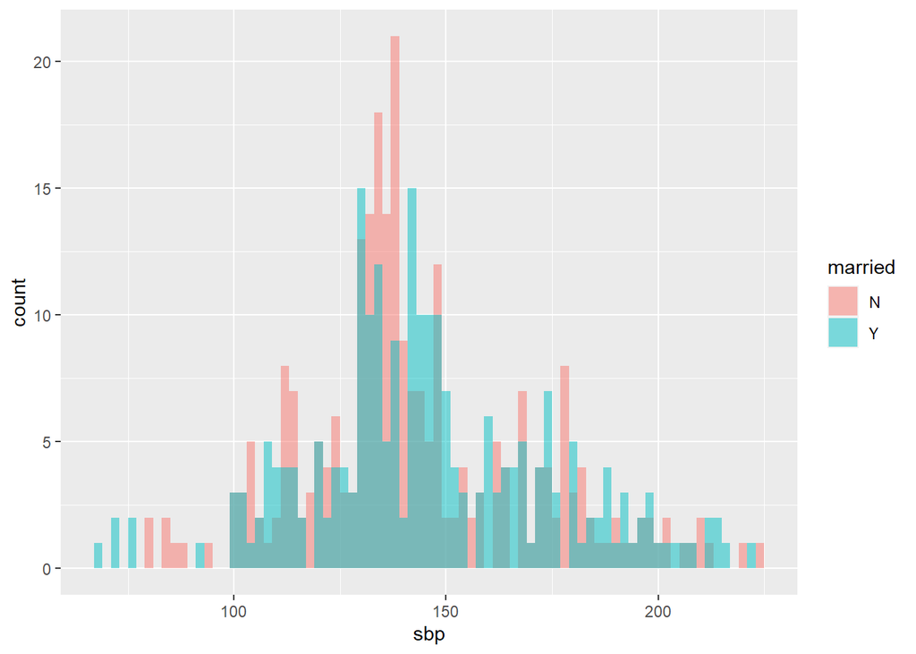

The medium exercise group tends to have the highest stress level.

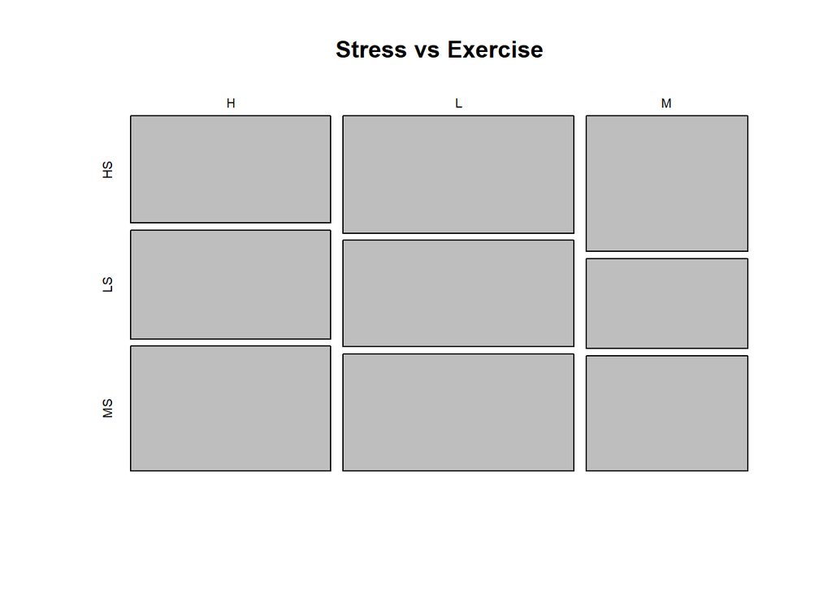

People who are married tend to have a higher proportion of lower stress levels

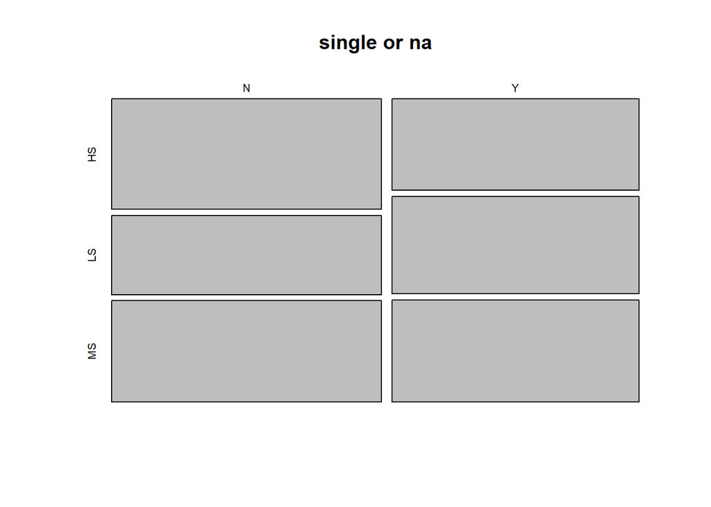

The lowest exercise group has the highest number of people.

```
##
##   H   L   M
## 169 195 136
```

The medium stress group has the most amount of high education subjects

```
##
##      HE LE ME
##   HS 57 60 57
##   LS 51 51 49
##   MS 62 60 53
```

The medium stress group has the highest average age.

```
##   stress      age
## 1     HS 40.53448
## 2     LS 39.18543
## 3     MS 40.73143
```

Females tend to have a lower average systolic blood pressure.

```
##   gender      sbp
## 1      F 144.8902
## 2      M 145.0212
```

```
## [1] 0.1758972
```

The test-statistic is:

```
##       t
## -1.3554
```

And the confidence interval is:

```
## [1] -8.3146  1.5259
## attr(,"conf.level")
## [1] 0.95
```

The difference of the average systolic blood pressure between married and non-married individuals is between -8.31 to 1.53.

```r
data1 = read.csv('GSK.csv')
library(ggplot2)
aggregate(sbp ~ stress, data = data1, mean)
aggregate(sbp ~ stress, data = data1, sd)

aggregate(age ~ exercise, data = data1, mean)
aggregate(age ~ exercise, data = data1, sd)

boxplot(age ~ educatn, data = data1, horizontal = TRUE)
ggplot(data1, aes(x=sbp, fill=married)) + geom_histogram(binwidth=2, alpha=.5, position="identity")
two.way = table(data1$exercise,data1$stress)
mosaicplot(two.way, main = "Stress vs Exercise")
two.way = table(data1$married,data1$stress)
mosaicplot(two.way, main = "single or na")
table(data1$exercise)
two.way = table(data1$stress,data1$educatn)
two.way
aggregate(age ~ stress, data = data1, mean)
aggregate(sbp ~ gender, data = data1, mean)

the.results = t.test(sbp ~ married, data = data1, var.equal = TRUE, level = 1-0.05)
pval = the.results$p.value
ts = round(the.results$statistic,4)
CI = round(the.results$conf.int,4)
pval
ts
CI
```